# Analyzing the Timing of Emergency Rental Assistance Programs During the COVID Pandemic

Peter Williams

08-27-2024

# 1 About this document

# 2 ERA1 and ERA2 Data

In each figure, we present data on cumulative housholds assisted by ERA1 and ERA2. This data is provided at https://home.treasury.gov/policy-issues/coronavirus/assistance-for-state-local-and-tribal-governments/emergency-rental-assistance-program/public-data in the ‘Emergency Rental Assistance Monthly Compliance Report: June 1-30, 2022’ file. I run the following code to read in the data on both ERA1 and ERA2 payments and calculate a cumulative sum presenting millions of households assisted.

```r
# Read in data on ERA1 Payments #
ERA1_Payment_Timeseries <- read_excel("Time Series Imports/June-2022-ERA-Monthly-Data.xlsx", sheet = "ERA1 Summary", range = "A3:C19", col_names = TRUE)
ERA1_Payment_Timeseries <- ERA1_Payment_Timeseries[,c(1,3)]
colnames(ERA1_Payment_Timeseries) <- c("Date", "Unique Households Assisted")
# Note the fact that 01/2021 - 03/2021 payments are grouped under 03/2021 #
ERA1_Payment_Timeseries$Date <- seq(as.Date("2021-04-01"), as.Date("2022-07-01"), by = "1 month") -1

# Read in data on ERA2 Payments #
ERA2_Payment_Timeseries <- read_excel("Time Series Imports/June-2022-ERA-Monthly-Data.xlsx", sheet = "ERA2 Summary", range = "A3:C16", col_names = TRUE)
ERA2_Payment_Timeseries <- ERA2_Payment_Timeseries[,c(1,3)]
colnames(ERA2_Payment_Timeseries) <- c("Date", "Unique Households Assisted")
# Note the fact that 01/2021 - 03/2021 payments are grouped under 03/2021 #
ERA2_Payment_Timeseries$Date <- seq(as.Date("2021-07-01"), as.Date("2022-07-01"), by = "1 month") -1

# Calculate cumulative ERA payments #
ERA_Payments <- data.frame(matrix(nrow = 16, ncol = 2))
colnames(ERA_Payments) <- c("Date", "Cumulative Households Assisted, ERA1 & ERA2")
ERA_Payments$Date <- ERA1_Payment_Timeseries$Date
for(i in 1:nrow(ERA_Payments)) {
  ERA_Payments$`Cumulative Households Assisted, ERA1 & ERA2`[i] <- sum(ERA1_Payment_Timeseries$`Unique Households Assisted`[ERA1_Payment_Timeseries$Date <= ERA_Payments$Date[i]]) + sum(ERA2_Payment_Timeseries$`Unique Households Assisted`[ERA2_Payment_Timeseries$Date <= ERA_Payments$Date[i]])
}

# Convert Households Assisted to millions #
ERA_Payments$`Cumulative Households Assisted, ERA1 & ERA2` <- ERA_Payments$`Cumulative Households Assisted, ERA1 & ERA2` / 1000000

# Create ID column for graph legend #
ERA_Payments$ID <- colnames(ERA_Payments)[2]
```

# 3 Disposable Income (Bottom 50% of Households)

Our first figure analyzes the disposable income level of the bottom 50% of households during the COVID-19 pandemic. This data comes from https://realtimeinequality.org/.

## 3.1 STATA

1. **01-import-nipa.do** - This is the first program I run. This imports the National Income and Product Accounts (NIPA) deflator that standardizes the income data.
2. **01-import-aid-covid.do** - This is the second program I run. This imports COVID-19 economic stimulus data. In order to run this code, you must download the ‘covid-aid-data.xlsx’ file from the ‘raw-data/covid-aid-data’ folder.
3. **01-import-dina.do** - This is the third program I run. This imports the monthly microfiles that they use to construct their data. In order to run this code, you must download the microfiles located at https://www.dropbox.com/scl/fi/2xg6klquck33meyt6go67/PSZ2022Dinafiles.zip?rlkey=0ywtis6bgjetw43xhx46f78hn&e=1&dl=0 (this link comes from https://gabriel-zucman.eu/usdina/ through the “Distributional national accounts micro-files” link) and replace the file path on line 6 with the location of the downloaded files. I also had to remove the ‘top400’ variable on line 17 from the ‘keep’ command due to a ‘missing variable’ error.
4. **01-import-ici.do** - This is the fourth program I run. This imports data from the Investment Company Institute (ICI).
5. **02-prepare-nipa.do** - This is the fifth program I run. This prepares the raw NIPA data. In order to compensate for errors while running the code, I removed line 537 (‘replace to_keep = 1 if series_code == “y672rc”’), line 595 (‘local disag_y672rc “b040rc”’), and all other occurrences of ‘y672rc’ in the code that were not commented out. I also replaced all occurrences of the ‘renvars’ command with the ‘rename’ command, accounting for subsequent differences in syntax. Further, for the ‘generate nipa_princ’ command on line 757, I added a conditional function that replaced missing values with 0. For example, ‘+ nipa_proprietors’ became ‘+ cond(missing(nipa_proprietors), 0, nipa_proprietors)’. Finally, I removed line 775 (‘assert reldif(nipa_princ, a032rc) < 1e-4 if yq(year, quarter) < yq(2022, 01)’) as every entry of the a032rc variable was missing and thus generating an error at this line.
6. **03-decompose-components.do** - This is the sixth program I run. This decomposes total income into its components. In order to run this code, you must remove the comment characters from lines 53 and 54 so that STATA runs the for loops for each list; to save time, you can also remove the ‘adult’ variable from line 54 as we are only concerned with the working-age data. You also must download all of the monthly microfiles located at https://www.dropbox.com/scl/fo/lacu5k5ndquxgo72nclyv/AOorwugG1jiiDcs5LuZFoeA?rlkey=b1y05p8no5s84drtof4q32bzn&e=1&dl=0 and replace the file path on line 64 with the location of the downloaded files. To save time, I only downloaded the monthly microfiles for 01/2019 - 03/2023, and I adjusted the data ranges at the top of the code to reflect this new range.

## 3.2 R

### 3.2.1 Reading the data

Once Stata has finished running, the data is ready to be read into RStudio. I run the following code to read the data into RStudio, combine it into a single data frame, subset only the bottom 50% of households, compute monthly averages, standardize it with the NIPA deflator produced through Stata, and store factor income and post-tax disposable income.

```r
# My methods for this section comes from the 04-plot-covid.do program in the realtimeinequality.org methodology.

# Read working age population income data produced by Stata files #
Princ_Working_Age_Data <- read_dta("STATA Exports/decomposition-monthly-princ-working_age.dta")
Peinc_Working_Age_Data <- read_dta("STATA Exports/decomposition-monthly-peinc-working_age.dta")
Dispo_Working_Age_Data <- read_dta("STATA Exports/decomposition-monthly-dispo-working_age.dta")
Poinc_Working_Age_Data <- read_dta("STATA Exports/decomposition-monthly-poinc-working_age.dta")

# Bind columns to create a single data frame, removing unnecessary and redundant columns #
Working_Age_Data <- bind_cols(Princ_Working_Age_Data[,c(1:4)], Poinc_Working_Age_Data[,-c(1:3,5)], Peinc_Working_Age_Data[,-c(1:3,5)], Dispo_Working_Age_Data[,-c(1:3,5)])

# Read in nipa deflator and add to working age data #
Nipa_Deflator <- read_dta("STATA Exports/nipa-simplified-monthly.dta")
Working_Age_Data$'Nipa Deflator' <- 0
for (i in 1:nrow(Working_Age_Data)) {
  Working_Age_Data$`Nipa Deflator`[i] <- Nipa_Deflator$nipa_deflator[Nipa_Deflator$year == Working_Age_Data$year[i] & Nipa_Deflator$month == Working_Age_Data$month[i]]
}

# Keep only bottom 50% of households #
Working_Age_Data <- Working_Age_Data[Working_Age_Data$p <= 49000,]
Working_Age_Data <- Working_Age_Data[,-3]

# Make a data frame of averages #
Income_Timeseries <- data.frame(matrix(nrow = 51, ncol = ncol(Working_Age_Data)))
colnames(Income_Timeseries) <- colnames(Working_Age_Data)
Income_Timeseries$year <- c(rep(2019,12), rep(2020,12), rep(2021,12), rep(2022,12), rep(2023,3))
Income_Timeseries$month <- c(rep(c(1:12),4),c(1:3))
for (i in 1:nrow(Income_Timeseries)) {
  for (j in 3:ncol(Income_Timeseries)) {
    Income_Timeseries[i,j] <- colMeans(Working_Age_Data[Working_Age_Data$year == Income_Timeseries$year[i] & Working_Age_Data$month == Income_Timeseries$month[i],j])
  }
}

# De-annualize and divide by the NIPA deflator #
for (i in 1:nrow(Income_Timeseries)) {
  for (j in 3:(ncol(Income_Timeseries) - 1)) {
    Income_Timeseries[i,j] <- Income_Timeseries[i,j] / 12 / Income_Timeseries$`Nipa Deflator`[i]
  }
}

# Create columns for graph #
Income_Timeseries$'Factor Income' <- Income_Timeseries$princ
Income_Timeseries$'Subsidized Factor Income' <- Income_Timeseries$princ + Income_Timeseries$covidsub
Income_Timeseries$'Subsidized Pretax National Income' <- Income_Timeseries$`Subsidized Factor Income` + Income_Timeseries$uiben + Income_Timeseries$penben - Income_Timeseries$contrib
Income_Timeseries$'Post-Tax Disposable Income' <- Income_Timeseries$`Subsidized Pretax National Income` + Income_Timeseries$vet + Income_Timeseries$othcash - Income_Timeseries$taxes - Income_Timeseries$estatetax - Income_Timeseries$corptax - Income_Timeseries$othercontrib + Income_Timeseries$covidrelief
Income_Timeseries$'Date' <- seq(as.Date("2019-02-01"), as.Date("2023-04-01"), by = "1 month") - 1
Income_Timeseries <- Income_Timeseries[,c(27:31)]

# Melt the graph for the legend #
Income_Timeseries$Date <- as.character(Income_Timeseries$Date)
Income_Timeseries_Melted <- melt(Income_Timeseries)
Income_Timeseries_Melted$Date <- seq(as.Date("2019-02-01"), as.Date("2023-04-01"), by = "1 month") - 1
colnames(Income_Timeseries_Melted) <- c("Date", "Type of Income", "Monthly Income per adult (constant USD)")

# Remove extra variables for line graphs #
Income_Timeseries_Melted_Factor_and_Disposable <- Income_Timeseries_Melted[Income_Timeseries_Melted$`Type of Income` %in% c("Factor Income", "Post-Tax Disposable Income"),]
```

### 3.2.2 Simplified Disposable Income graph

This figure plots the factor income and disposable income of the bottom 50% of households from January 2019 to March 2023 alongside emergency rental assistance programs.

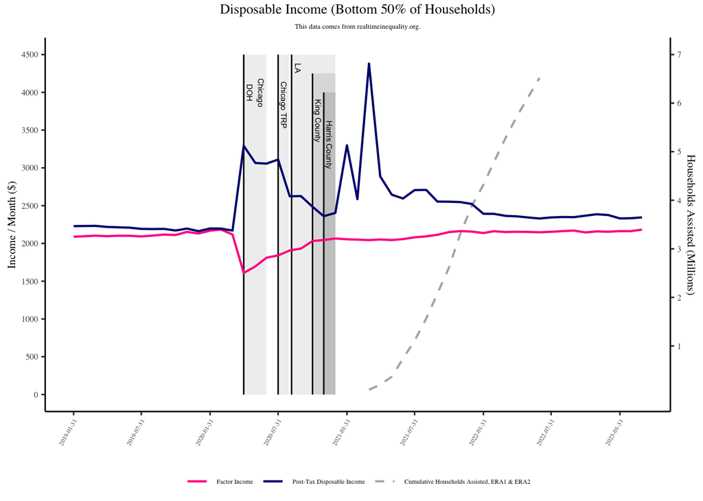

```r
# Specify colors #
Colors <- c("Factor Income" = "deeppink", "Post-Tax Disposable Income" = "navyblue", "Cumulative Households Assisted, ERA1 & ERA2" = "grey70")

# Graph income of the bottom 50% of households from January 2019 to March 2023 #
Income_Timeseries_Graph <-
  ggplot() +
  geom_ribbon(
    aes(x = c(as.Date("2020-04-30"), as.Date("2020-06-30")), ymax = c(4500,4500), ymin = c(0,0)),
    color = NA,
    alpha = 0.6,
    fill = "grey90"
  ) +
  geom_ribbon(
    aes(x = c(as.Date("2020-07-31"), as.Date("2020-08-29")), ymax = c(4500,4500), ymin = c(0,0)),
    color = NA,
    alpha = 0.6,
    fill = "grey90"
  ) +
  geom_ribbon(
    aes(x = c(as.Date("2020-11-30"), as.Date("2020-12-31")), ymax = c(4000,4000), ymin = c(0,0)),
    color = NA,
    alpha = 1,
    fill = "grey50"
  ) +
  geom_ribbon(
    aes(x = c(as.Date("2020-10-31"), as.Date("2020-12-31")), ymax = c(4250,4250), ymin= c(0,0)),
    color = NA,
    alpha = 0.6,
    fill = "grey70"
  ) +
  geom_ribbon(
    aes(x = c(as.Date("2020-09-05"), as.Date("2020-12-31")), ymax = c(4500,4500), ymin = c(0,0)),
    color = NA,
    alpha = 0.6,
    fill = "grey90"
  ) +
  geom_line(
    ERA_Payments,
    mapping = aes(y = `Cumulative Households Assisted, ERA1 & ERA2` / 7 * 4500, x = Date, color = ID),
    linewidth = 0.75,
    linetype = "dashed"
  ) +
  geom_segment(
    aes(x = as.Date("2020-04-30"), xend = as.Date("2020-04-30"), y = 0, yend = 4500),
    color = "black",
    linewidth = 0.5
  ) +
  geom_segment(
    aes(x = as.Date("2020-07-31"), xend = as.Date("2020-07-31"), y = 0, yend = 4500),
    color = "black",
    linewidth = 0.5
  ) +
  geom_segment(
    aes(x = as.Date("2020-11-30"), xend = as.Date("2020-11-30"), y = 0, yend = 4000),
    color = "black",
    linewidth = 0.5
  ) +
  geom_segment(
    aes(x = as.Date("2020-10-31"), xend = as.Date("2020-10-31"), y = 0, yend = 4250),
    color = "black",
    linewidth = 0.5
  ) +
  geom_segment(
    aes(x = as.Date("2020-09-05"), xend = as.Date("2020-09-05"), y = 0, yend = 4500),
    color = "black",
    linewidth = 0.5
  ) +
  geom_line(
    Income_Timeseries_Melted_Factor_and_Disposable,
    mapping = aes(y = `Monthly Income per adult (constant USD)`, x = `Date`, group = `Type of Income`, color = `Type of Income`),
    linewidth = 0.75
  ) +
  annotate(
    "text", x = as.Date("2020-05-31"), y = 4000, label= "Chicago\nDOH", angle = 270, size = 2, color="black"
  ) +
  annotate(
    "text", x = as.Date("2020-08-15"), y = 3837, label="Chicago TRP", angle = 270, size = 2, color="black"
  ) +
  annotate(
    "text", x = as.Date("2020-12-15"), y = 3312, label="Harris County", angle=270, size = 2, color="black"
  ) +
  annotate(
    "text", x = as.Date("2020-11-15"), y = 3625, label="King County", angle=270, size = 2, color="black"
  ) +
  annotate(
    "text", x = as.Date("2020-09-22"), y = 4325, label="LA", angle=270, size = 2, color="black"
  ) +
  labs(
    title = paste0("Disposable Income (Bottom 50% of Households)"),
    subtitle = "This data comes from realtimeinequality.org.",
    y = "Income / Month ($)",
    x = ""
  ) +
  theme_bw() +
  theme(
    text = element_text(family = "Times"),
    plot.title = element_text(size = 10, hjust = 0.5),
    plot.subtitle = element_text(size = 5, hjust = 0.5),
    plot.margin = margin(0.1,0.2,0,0.2, "cm"),
    axis.text = element_text(size = 6, margin = 1),
    axis.title = element_text(size = 8, margin = 1),
    axis.title.x = element_blank(),
    axis.text.x = element_text(angle = 60, vjust = 1, hjust=1, size = 4.5),
    panel.grid = element_blank(),
    panel.border = element_blank(),
    panel.background = element_blank(),
    legend.text = element_text(size = 4.5),
    legend.title = element_blank(),
    legend.spacing.x = unit(0.01, "cm"),
    legend.spacing.y = unit(0.2, "mm"),
    legend.position = "inside",
    legend.position.inside = c(0.83,0.23),
    legend.background = element_blank(),
    axis.line = element_line(colour = "black")
  ) +
  ylab(
    label = "Income / Month ($)"
  ) +
  scale_x_date(
    breaks = seq(as.Date("2019-02-01"), as.Date("2023-04-01"), by = "6 months") - 1
  ) +
  scale_color_manual(
    values = Colors,
    name = "",
    breaks = c("Factor Income", "Post-Tax Disposable Income", "Cumulative Households Assisted, ERA1 & ERA2")
  ) +
  guides(
    color = guide_legend(override.aes = list(linetype = c("solid", "solid", "dashed")), nrow = 1, position = "bottom")
  ) +
  scale_y_continuous(
    limits = c(0,4500),
    breaks = seq(0, 4500, by = 500),
    sec.axis = sec_axis(transform = ~./ 4500 * 7, name = "Households Assisted (Millions)", breaks = seq(1, 7, by = 1))
  )

Income_Timeseries_Graph
```

### 3.2.3 Detailed Disposable Income Graph

This figure plots the factor income, disposable income, and the factors that contributed to the differences between the two for the bottom 50% of households from January 2019 to March 2023 alongside emergency rental assistance programs.

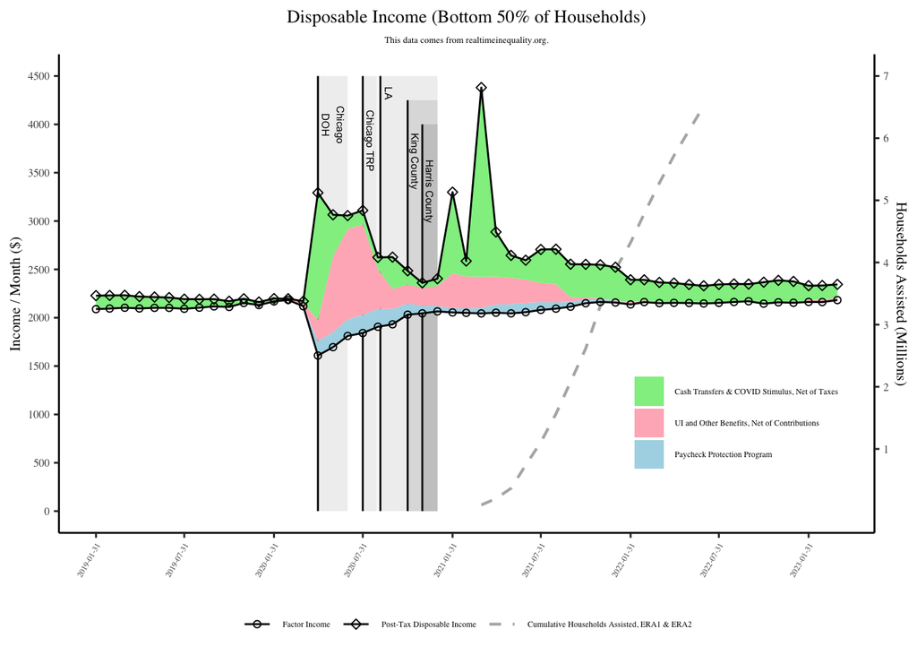

```r
# Specify 'Lower' & 'Fill' variables for geom_ribbon #
for (i in 1:nrow(Income_Timeseries_Melted)) {
  if (Income_Timeseries_Melted$`Type of Income`[i] == "Factor Income") {
    Income_Timeseries_Melted$Lower[i] <- Income_Timeseries_Melted$`Monthly Income per adult (constant USD)`[Income_Timeseries_Melted$Date == Income_Timeseries_Melted$Date[i] & Income_Timeseries_Melted$`Type of Income` == "Factor Income"]
    Income_Timeseries_Melted$Fill[i] <- NA
  }
  if (Income_Timeseries_Melted$`Type of Income`[i] == "Subsidized Factor Income") {
    Income_Timeseries_Melted$Lower[i] <- Income_Timeseries_Melted$`Monthly Income per adult (constant USD)`[Income_Timeseries_Melted$Date == Income_Timeseries_Melted$Date[i] & Income_Timeseries_Melted$`Type of Income` == "Factor Income"]
    Income_Timeseries_Melted$Fill[i] <- "Paycheck Protection Program"
  }
  if (Income_Timeseries_Melted$`Type of Income`[i] == "Subsidized Pretax National Income") {
    Income_Timeseries_Melted$Lower[i] <- Income_Timeseries_Melted$`Monthly Income per adult (constant USD)`[Income_Timeseries_Melted$Date == Income_Timeseries_Melted$Date[i] & Income_Timeseries_Melted$`Type of Income` == "Subsidized Factor Income"]
    Income_Timeseries_Melted$Fill[i] <- "UI and Other Benefits, Net of Contributions"
  }
  if (Income_Timeseries_Melted$`Type of Income`[i] == "Post-Tax Disposable Income") {
    Income_Timeseries_Melted$Lower[i] <- Income_Timeseries_Melted$`Monthly Income per adult (constant USD)`[Income_Timeseries_Melted$Date == Income_Timeseries_Melted$Date[i] & Income_Timeseries_Melted$`Type of Income` == "Subsidized Pretax National Income"]
    Income_Timeseries_Melted$Fill[i] <- "Cash Transfers & COVID Stimulus, Net of Taxes"
  }
}
Income_Timeseries_Melted$Lower <- as.numeric(Income_Timeseries_Melted$Lower)

# Specify colors, shapes, & fill #
Colors <- c("Factor Income" = "black", "Post-Tax Disposable Income" = "black", "Cumulative Households Assisted, ERA1 & ERA2" = "grey70")
Shapes <- c("Factor Income" = 1, "Subsidized Factor Income" = 0, "Subsidized Pretax National Income" = 2,
            "Post-Tax Disposable Income" = 5)
Fills <- c("Paycheck Protection Program" = "lightblue", "UI and Other Benefits, Net of Contributions" = "lightpink", "Cash Transfers & COVID Stimulus, Net of Taxes" = "lightgreen")


# Graph income of the bottom 50% of households from January 2019 to March 2023 #
Income_Timeseries_Detail_Graph <-
  ggplot() +
  geom_ribbon(
    aes(x = c(as.Date("2020-04-30"), as.Date("2020-06-30")), ymax = c(4500,4500), ymin = c(0,0)),
    color = NA,
    alpha = 0.6,
    fill = "grey90"
  ) +
  geom_ribbon(
    aes(x = c(as.Date("2020-07-31"), as.Date("2020-08-29")), ymax = c(4500,4500), ymin = c(0,0)),
    color = NA,
    alpha = 0.6,
    fill = "grey90"
  ) +
  geom_ribbon(
    aes(x = c(as.Date("2020-11-30"), as.Date("2020-12-31")), ymax = c(4000,4000), ymin = c(0,0)),
    color = NA,
    alpha = 1,
    fill = "grey50"
  ) +
  geom_ribbon(
    aes(x = c(as.Date("2020-10-31"), as.Date("2020-12-31")), ymax = c(4250,4250), ymin= c(0,0)),
    color = NA,
    alpha = 0.6,
    fill = "grey70"
  ) +
  geom_ribbon(
    aes(x = c(as.Date("2020-09-05"), as.Date("2020-12-31")), ymax = c(4500,4500), ymin = c(0,0)),
    color = NA,
    alpha = 0.6,
    fill = "grey90"
  ) +
  geom_line(
    ERA_Payments,
    mapping = aes(y = `Cumulative Households Assisted, ERA1 & ERA2` / 7 * 4500, x = Date, color = ID),
    linewidth = 0.75,
    linetype = "dashed"
  ) +
  geom_segment(
    aes(x = as.Date("2020-04-30"), xend = as.Date("2020-04-30"), y = 0, yend = 4500),
    color = "black",
    linewidth = 0.5
  ) +
  geom_segment(
    aes(x = as.Date("2020-07-31"), xend = as.Date("2020-07-31"), y = 0, yend = 4500),
    color = "black",
    linewidth = 0.5
  ) +
  geom_segment(
    aes(x = as.Date("2020-11-30"), xend = as.Date("2020-11-30"), y = 0, yend = 4000),
    color = "black",
    linewidth = 0.5
  ) +
  geom_segment(
    aes(x = as.Date("2020-10-31"), xend = as.Date("2020-10-31"), y = 0, yend = 4250),
    color = "black",
    linewidth = 0.5
  ) +
  geom_segment(
    aes(x = as.Date("2020-09-05"), xend = as.Date("2020-09-05"), y = 0, yend = 4500),
    color = "black",
    linewidth = 0.5
  ) +
  geom_ribbon(
    Income_Timeseries_Melted,
    mapping = aes(ymax = `Monthly Income per adult (constant USD)`, ymin = Lower, x = Date, group = `Type of Income`, fill = Fill),
  ) +
  geom_line(
    Income_Timeseries_Melted_Factor_and_Disposable,
    mapping = aes(y = `Monthly Income per adult (constant USD)`, x = `Date`, group = `Type of Income`, color = `Type of Income`),
  ) +
  geom_point(
    Income_Timeseries_Melted_Factor_and_Disposable,
    mapping = aes(y = `Monthly Income per adult (constant USD)`, x = `Date`, group = `Type of Income`, color = `Type of Income`, shape = `Type of Income`, color = `Type of Income`, shape = `Type of Income`),
  ) +
  annotate(
    "text", x = as.Date("2020-05-31"), y = 4000, label= "Chicago\nDOH", angle = 270, size = 2, color="black"
  ) +
  annotate(
    "text", x = as.Date("2020-08-15"), y = 3837, label="Chicago TRP", angle = 270, size = 2, color="black"
  ) +
  annotate(
    "text", x = as.Date("2020-12-15"), y = 3312, label="Harris County", angle=270, size = 2, color="black"
  ) +
  annotate(
    "text", x = as.Date("2020-11-15"), y = 3625, label="King County", angle=270, size = 2, color="black"
  ) +
  annotate(
    "text", x = as.Date("2020-09-22"), y = 4325, label="LA", angle=270, size = 2, color="black"
  ) +
  labs(
    title = paste0("Disposable Income (Bottom 50% of Households)"),
    subtitle = "This data comes from realtimeinequality.org.",
    y = "Income / Month ($)",
    x = ""
  ) +
  theme_bw() +
  theme(
    text = element_text(family = "Times"),
    plot.title = element_text(size = 10, hjust = 0.5),
    plot.subtitle = element_text(size = 5, hjust = 0.5),
    plot.margin = margin(0.2,0.2,0.1,0.2, "cm"),
    axis.text = element_text(size = 6, margin = 1),
    axis.title = element_text(size = 8, margin = 1),
    axis.title.x = element_blank(),
    axis.text.x = element_text(angle = 60, vjust = 1, hjust=1, size = 4.5),
    panel.grid = element_blank(),
    panel.border = element_blank(),
    panel.background = element_blank(),
    legend.text = element_text(size = 4.5),
    legend.title = element_blank(),
    legend.spacing.x = unit(0.01, "cm"),
    legend.spacing.y = unit(0.2, "mm"),
    legend.position = "inside",
    legend.position.inside = c(0.83,0.23),
    legend.background = element_blank(),
    axis.line = element_line(colour = "black")
  ) +
  ylab(
    label = "Income / Month ($)"
  ) +
  scale_x_date(
    breaks = seq(as.Date("2019-02-01"), as.Date("2023-04-01"), by = "6 months") - 1
  ) +
  scale_color_manual(
    values = Colors,
    name = "",
    breaks = c("Factor Income", "Post-Tax Disposable Income", "Cumulative Households Assisted, ERA1 & ERA2")
  ) +
  scale_shape_manual(
    values = Shapes
  ) +
  scale_fill_manual(
    values = Fills,
    na.translate = F,
    breaks = c("Cash Transfers & COVID Stimulus, Net of Taxes", "UI and Other Benefits, Net of Contributions", "Paycheck Protection Program")
  ) +
  guides(
    color = guide_legend(override.aes = list(linetype = c("solid", "solid", "dashed"), shape = c(1,5,NA)), nrow = 1, position = "bottom"),
    shape = "none",
    fill = guide_legend(nrow = 3)
  ) +
  scale_y_continuous(
    limits = c(0,4500),
    breaks = seq(0, 4500, by = 500),
    sec.axis = sec_axis(transform = ~./ 4500 * 7, name = "Households Assisted (Millions)", breaks = seq(1, 7, by = 1))
  )

Income_Timeseries_Detail_Graph
```

# 4 Unemployment

Our second figure graphs uses unemployment rate data from the Bureau of Labor Statistics at https://data.bls.gov/timeseries/LNS14000000.

## 4.1 Reading the data

To read in the data, you must download a spreadsheet (.xlsx) file from the Bureau of Labor Statistics link provided above. I left the date range as 2014 to 2024 and adjusted by code accordingly.

```r
# Read data from https://data.bls.gov/timeseries/LNS14000000 #
Unemployment_Rate <- read_excel("Time Series Imports/Unemployment Rate (BLS).xlsx", range = "A12:M22", col_names = TRUE)
Unemployment_Timeseries <- data.frame(matrix(nrow = 51, ncol = 2))
colnames(Unemployment_Timeseries) <- c("Date", "Unemployment Rate (%)")
Unemployment_Timeseries$Date <- seq(as.Date("2019-02-01"), as.Date("2023-04-01"), by = "1 month") - 1
Unemployment_Timeseries$`Unemployment Rate (%)` <- as.numeric(c(Unemployment_Rate[6,c(2:13)], Unemployment_Rate[7,c(2:13)], Unemployment_Rate[8,c(2:13)], Unemployment_Rate[9,c(2:13)], Unemployment_Rate[10,c(2:4)]))

# Assign an ID for the graph legend #
Unemployment_Timeseries$ID <- "Unemployment Rate (%)"
```

## 4.2 Creating the figure

This figure graphs the unemployment rate from January 2019 to March 2023 alongside emergency rental assistance programs.

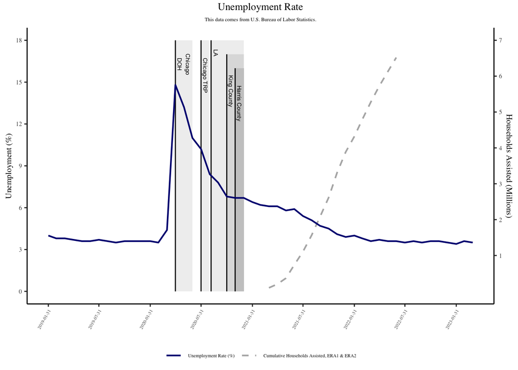

```r
# Specify colors #
Colors <- c("Cumulative Households Assisted, ERA1 & ERA2" = "grey70", "Unemployment Rate (%)" = "navyblue")

# Graph unemployment from January 2019 to March 2023 #
Unemployment_Timeseries_Graph <-
  ggplot() +
  geom_ribbon(
    aes(x = c(as.Date("2020-04-30"), as.Date("2020-06-30")), ymax = c(18,18), ymin = c(0,0)),
    color = NA,
    alpha = 0.6,
    fill = "grey90"
  ) +
  geom_ribbon(
    aes(x = c(as.Date("2020-07-31"), as.Date("2020-08-29")), ymax = c(18,18), ymin = c(0,0)),
    color = NA,
    alpha = 0.6,
    fill = "grey90"
  ) +
  geom_ribbon(
    aes(x = c(as.Date("2020-11-30"), as.Date("2020-12-31")), ymax = c(16,16), ymin = c(0,0)),
    color = NA,
    alpha = 1,
    fill = "grey50"
  ) +
  geom_ribbon(
    aes(x = c(as.Date("2020-10-31"), as.Date("2020-12-31")), ymax = c(17,17), ymin= c(0,0)),
    color = NA,
    alpha = 0.6,
    fill = "grey70"
  ) +
  geom_ribbon(
    aes(x = c(as.Date("2020-09-01"), as.Date("2020-12-31")), ymax = c(18,18), ymin = c(0,0)),
    color = NA,
    alpha = 0.6,
    fill = "grey90"
  ) +
  geom_line(
    ERA_Payments,
    mapping = aes(y = `Cumulative Households Assisted, ERA1 & ERA2` / 7 * 18, x = Date, color = ID),
    linewidth = 0.75,
    linetype = "dashed"
  ) +
  geom_segment(
    aes(x = as.Date("2020-04-30"), xend = as.Date("2020-04-30"), y = 0, yend = 18),
    color = "black",
    linewidth = 0.5
  ) +
  geom_segment(
    aes(x = as.Date("2020-07-31"), xend = as.Date("2020-07-31"), y = 0, yend = 18),
    color = "black",
    linewidth = 0.5
  ) +
  geom_segment(
    aes(x = as.Date("2020-11-30"), xend = as.Date("2020-11-30"), y = 0, yend = 16),
    color = "black",
    linewidth = 0.5
  ) +
  geom_segment(
    aes(x = as.Date("2020-10-31"), xend = as.Date("2020-10-31"), y = 0, yend = 17),
    color = "black",
    linewidth = 0.5
  ) +
  geom_segment(
    aes(x = as.Date("2020-09-05"), xend = as.Date("2020-09-05"), y = 0, yend = 18),
    color = "black",
    linewidth = 0.5
  ) +
  geom_line(
    Unemployment_Timeseries,
    mapping = aes(y = `Unemployment Rate (%)`, x = `Date`, color = ID),
    linewidth = 0.75
  ) +
  annotate(
    "text", x = as.Date("2020-05-30"), y = 16.3, label= " Chicago \nDOH", angle = 270, size = 2, color="black"
  ) +
  annotate(
    "text", x = as.Date("2020-08-15"), y = 15.5, label="Chicago TRP", angle = 270, size = 2, color="black"
  ) +
  annotate(
    "text", x = as.Date("2020-12-15"), y = 13.5, label="Harris County", angle=270, size = 2, color="black"
  ) +
  annotate(
    "text", x = as.Date("2020-11-15"), y = 14.37, label="King County", angle=270, size = 2, color="black"
  ) +
  annotate(
    "text", x = as.Date("2020-09-22"), y = 17.12, label="LA", angle=270, size = 2, color="black"
  ) +
  labs(
    title = paste0("Unemployment Rate"),
    subtitle = "This data comes from U.S. Bureau of Labor Statistics.",
    y = "Unemployment (%)",
    x = ""
  ) +
  theme(
    text = element_text(family = "Times"),
    plot.title = element_text(size = 10, hjust = 0.5),
    plot.subtitle = element_text(size = 5, hjust = 0.5),
    plot.margin = margin(0.1,0.2,0,0.2, "cm"),
    axis.text = element_text(size = 6, margin = 1),
    axis.title = element_text(size = 8, margin = 1),
    axis.title.x = element_blank(),
    axis.text.x = element_text(angle = 60, vjust = 1, hjust=1, size = 4.5),
    panel.grid = element_blank(),
    panel.border = element_blank(),
    panel.background = element_blank(),
    legend.text = element_text(size = 4.5),
    legend.title = element_blank(),
    legend.spacing.x = unit(1, "cm"),
    legend.spacing.y = unit(0.2, "mm"),
    legend.position = "bottom",
    legend.background = element_blank(),
    axis.line = element_line(colour = "black")
  ) +
  ylab(
    label = "Unemployment (%)"
  ) +
  scale_y_continuous(
    limits = c(0,18),
    breaks = seq(0,18, by = 3),
    sec.axis = sec_axis(transform = ~./18 * 7, name = "Households Assisted (Millions)", breaks = seq(1, 7, by = 1))
  ) +
  scale_x_date(
    breaks = seq(as.Date("2019-02-01"), as.Date("2023-04-01"), by = "6 months") - 1
  ) +
  scale_color_manual(
    values = Colors,
    breaks = c("Unemployment Rate (%)", "Cumulative Households Assisted, ERA1 & ERA2")
  ) +
  guides(
    color = guide_legend(position = "bottom")
  )

Unemployment_Timeseries_Graph
```

# 5 Household Pulse Survey Statistics

Our third figure presents data from the U.S. Census Bureau’s Household Pulse survey at https://www.census.gov/programs-surveys/household-pulse-survey/data/tables.html.

## 5.1 Reading the data

In order to read the data into R, I manually downloaded the available housing 1b, 2b, and 3b tables for weeks 1 through 63 onto my computer. The 2b and 3b tables are not available for the entire period.

```r
# Read in data on households in rental arrears #
Behind_On_Rent_Filenames <- list.files(path = "./Household Pulse Survey Files/", pattern = "housing1b*")
Behind_On_Rent_Filenames <- Behind_On_Rent_Filenames[order(as.numeric(str_replace(str_sub(Behind_On_Rent_Filenames,15,16), pattern = "[.]", replacement = "")), decreasing = FALSE)]
Behind_On_Rent_Data <- data.frame(matrix(nrow = length(Behind_On_Rent_Filenames), ncol = 1))
colnames(Behind_On_Rent_Data) <- "Households in Rental Arrears"
for (i in 1:nrow(Behind_On_Rent_Data)) {
  Temporary_Data <- read_excel(paste0("Household Pulse Survey Files/", Behind_On_Rent_Filenames[i]), sheet = "US")
  # Select the row where the first column == 'Total' or 'Total*' #
  Row_Number <- as.logical(unlist(lapply(Temporary_Data[,1], grepl, pattern = "Total"))) == TRUE & as.numeric(unlist(lapply(Temporary_Data[,1], nchar))) <= 6  & is.na(Temporary_Data[,1]) == FALSE
  # Select the first row where the first column = 'NA' and then select the column where 'Last month's payment status' = 'No' #
  Column_Number <- Temporary_Data[is.na(Temporary_Data[,1]),][1,] == "No" & is.na(Temporary_Data[is.na(Temporary_Data[,1]),][1,]) == FALSE
  # Take 'Last month's payment status' = 'No'
  Behind_On_Rent_Data[i,1] <- as.numeric(Temporary_Data[Row_Number, Column_Number[1,]]) / 1000000
}

# Assign dates based on the Pulse Survey dates #
Behind_On_Rent_Data$Date <- c(seq(as.Date("2020-05-05"), as.Date("2020-07-21"), by = "1 week"),
                              seq(as.Date("2020-8-31"), as.Date("2020-12-21"), by = "2 weeks"),
                              seq(as.Date("2021-01-18"), as.Date("2021-03-29"), by = "2 weeks"),
                              seq(as.Date("2021-04-25"), as.Date("2021-07-05"), by = "2 weeks"),
                              seq(as.Date("2021-08-02"), as.Date("2021-10-11"), by = "2 weeks"),
                              as.Date("2021-12-13"), as.Date("2022-01-10"), as.Date("2022-02-07"),
                              seq(as.Date("2022-03-14"), as.Date("2022-05-09"), by = "4 weeks"),
                              as.Date("2022-06-13"), as.Date("2022-07-11"), as.Date("2022-08-08"),
                              as.Date("2022-09-26"), as.Date("2022-10-17"), as.Date("2022-11-14"),
                              seq(as.Date("2022-12-19"), as.Date("2023-05-08"), by = "4 weeks"),
                              as.Date("2023-06-19"), as.Date("2023-07-10"), as.Date("2023-08-7"),
                              as.Date("2023-09-04"), as.Date("2023-10-02"), as.Date("2023-10-30"))

# Keep only the data through the end of March 2023 #
Behind_On_Rent_Data <- Behind_On_Rent_Data[c(1:56),]

# Assign an ID for the graph legend #
Behind_On_Rent_Data$ID <- "Households in Rental Arrears"

# Read in data on Households at risk of foreclosure #
Eviction_Risk_Filenames <- list.files(path = "./Household Pulse Survey Files/", pattern = "housing3b*")
Eviction_Risk_Filenames <- Eviction_Risk_Filenames[order(as.numeric(str_replace(str_sub(Eviction_Risk_Filenames,15,16), pattern = "[.]", replacement = "")), decreasing = FALSE)]
Eviction_Risk_Data <- data.frame(matrix(nrow = length(Eviction_Risk_Filenames), ncol = 1))
colnames(Eviction_Risk_Data) <- "Households in Rental Arrears at Risk of Eviction"
for (i in 1:nrow(Eviction_Risk_Data)) {
  Temporary_Data <- read_excel(paste0("Household Pulse Survey Files/", Eviction_Risk_Filenames[i]), sheet = "US")
  # Select the row where the first column == 'Total' or 'Total*' #
  Row_Number <- as.logical(unlist(lapply(Temporary_Data[,1], grepl, pattern = "Total"))) == TRUE & as.numeric(unlist(lapply(Temporary_Data[,1], nchar))) <= 6  & is.na(Temporary_Data[,1]) == FALSE
  # Select the first row where the first column = 'NA' and then select the column where 'Likelihood of leaving this home due to eviction in the next two months' = 'Very Likely' #
  Column_Number_1 <- Temporary_Data[is.na(Temporary_Data[,1]),][1,] == "Very likely" & is.na(Temporary_Data[is.na(Temporary_Data[,1]),][1,]) == FALSE
  # Select the first row where the first column = 'NA' and then select the column where 'Likelihood of leaving this home due to eviction in the next two months' = 'Somewhat Likely' #
  Column_Number_2 <- Temporary_Data[is.na(Temporary_Data[,1]),][1,] == "Somewhat likely" & is.na(Temporary_Data[is.na(Temporary_Data[,1]),][1,]) == FALSE
  # Take 'Likelihood of leaving this home due to eviction in the next two months' = ('Very likely' + 'Somewhat likely') / 'Total'
  Eviction_Risk_Data[i,1] <- (as.numeric(Temporary_Data[Row_Number, Column_Number_1[1,]]) + as.numeric(Temporary_Data[Row_Number, Column_Number_2[1,]])) / 1000000
}

# Assign dates based on the Pulse Survey dates #
Eviction_Risk_Data$Date <- c(seq(as.Date("2020-8-31"), as.Date("2020-12-21"), by = "2 weeks"),
                              seq(as.Date("2021-01-18"), as.Date("2021-03-29"), by = "2 weeks"),
                              seq(as.Date("2021-04-25"), as.Date("2021-07-05"), by = "2 weeks"),
                              seq(as.Date("2021-08-02"), as.Date("2021-10-11"), by = "2 weeks"),
                              as.Date("2021-12-13"), as.Date("2022-01-10"), as.Date("2022-02-07"),
                              seq(as.Date("2022-03-14"), as.Date("2022-05-09"), by = "4 weeks"),
                              as.Date("2022-06-13"), as.Date("2022-07-11"), as.Date("2022-08-08"),
                              as.Date("2022-09-26"), as.Date("2022-10-17"), as.Date("2022-11-14"),
                              seq(as.Date("2022-12-19"), as.Date("2023-05-08"), by = "4 weeks"),
                              as.Date("2023-06-19"), as.Date("2023-07-10"), as.Date("2023-08-7"),
                              as.Date("2023-09-04"), as.Date("2023-10-02"), as.Date("2023-10-30"))

# Keep only the data through the end of March 2023 #
Eviction_Risk_Data <- Eviction_Risk_Data[c(1:44),]

# Assign ID for legend purposes #
Eviction_Risk_Data$ID <- "Households in Rental Arrears at Risk of Eviction"

# Read in data on proportion of households that are unconfident in their ability to pay the next month's rent #
Next_Rent_Risk_Filenames <- list.files(path = "./Household Pulse Survey Files/", pattern = "housing2b*")
Next_Rent_Risk_Filenames <- Next_Rent_Risk_Filenames[order(as.numeric(str_replace(str_sub(Next_Rent_Risk_Filenames,15,16), pattern = "[.]", replacement = "")), decreasing = FALSE)]
Next_Rent_Risk_Data <- data.frame(matrix(nrow = length(Next_Rent_Risk_Filenames), ncol = 1))
colnames(Next_Rent_Risk_Data) <- "Households Unconfident in Next Month's Rent Payment"
for (i in 1:nrow(Next_Rent_Risk_Data)) {
  Temporary_Data <- read_excel(paste0("Household Pulse Survey Files/", Next_Rent_Risk_Filenames[i]), sheet = "US")
  # Select the row where the first column == 'Total' or 'Total*' #
  Row_Number <- as.logical(unlist(lapply(Temporary_Data[,1], grepl, pattern = "Total"))) == TRUE & as.numeric(unlist(lapply(Temporary_Data[,1], nchar))) <= 6  & is.na(Temporary_Data[,1]) == FALSE
  # Select the first row where the first column = 'NA' and then select the column where 'Confidence to pay next month's rent = 'No confidence' #
  Column_Number <- Temporary_Data[is.na(Temporary_Data[,1]),][1,] %in% c("No confidence", "No at all confident") & is.na(Temporary_Data[is.na(Temporary_Data[,1]),][1,]) == FALSE
  # Take 'Confidence to pay next month's rent' = 'No confidence' / 'Total'
  Next_Rent_Risk_Data[i,1] <- as.numeric(Temporary_Data[Row_Number, Column_Number[1,]]) / 1000000
}

# Assign dates based on the Pulse Survey dates #
Next_Rent_Risk_Data$Date <- c(seq(as.Date("2020-05-05"), as.Date("2020-07-21"), by = "1 week"),
                              seq(as.Date("2020-8-31"), as.Date("2020-12-21"), by = "2 weeks"),
                              seq(as.Date("2021-01-18"), as.Date("2021-03-29"), by = "2 weeks"),
                              seq(as.Date("2021-04-25"), as.Date("2021-07-05"), by = "2 weeks"),
                              seq(as.Date("2021-08-02"), as.Date("2021-10-11"), by = "2 weeks"),
                              as.Date("2021-12-13"), as.Date("2022-01-10"), as.Date("2022-02-07"),
                              seq(as.Date("2022-03-14"), as.Date("2022-05-09"), by = "4 weeks"))

# Assign ID for legend purposes #
Next_Rent_Risk_Data$ID <- "Households Unconfident in Next Month's Rent Payment"
```

## 5.2 Creating the figure

This figure plots the total number of households in rental arrears, the total number of households in rental arrears that are at risk of eviction, and the total number of households unconfident in next month’s rent payment from January 2019 to March 2023 alongside emergency rental assistance programs.

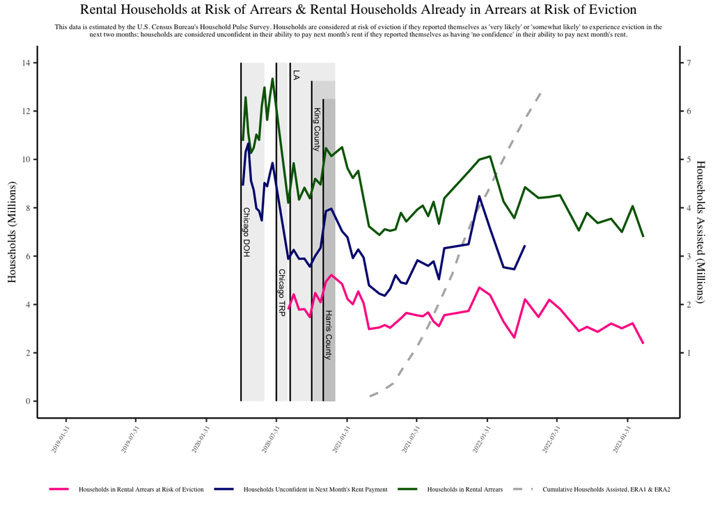

```r
# Specify colors #
Colors <- c("Households in Rental Arrears at Risk of Eviction" = "deeppink", "Households Unconfident in Next Month's Rent Payment" = "navyblue",
            "Households in Rental Arrears" = "darkgreen", "Cumulative Households Assisted, ERA1 & ERA2" = "grey70")

# Graph the Household Pulse Survey data #
Household_Pulse_Survey_Graph <-
  ggplot() +
  geom_ribbon(
    aes(x = c(as.Date("2020-04-30"), as.Date("2020-06-30")), ymax = c(14,14), ymin = c(0,0)),
    color = NA,
    alpha = 0.6,
    fill = "grey90"
  ) +
  geom_ribbon(
    aes(x = c(as.Date("2020-07-31"), as.Date("2020-08-29")), ymax = c(14,14), ymin = c(0,0)),
    color = NA,
    alpha = 0.6,
    fill = "grey90"
  ) +
  geom_ribbon(
    aes(x = c(as.Date("2020-11-30"), as.Date("2020-12-31")), ymax = c(12.5,12.5), ymin = c(0,0)),
    color = NA,
    alpha = 1,
    fill = "grey50"
  ) +
  geom_ribbon(
    aes(x = c(as.Date("2020-10-31"), as.Date("2020-12-31")), ymax = c(13.25,13.25), ymin= c(0,0)),
    color = NA,
    alpha = 0.6,
    fill = "grey70"
  ) +
  geom_ribbon(
    aes(x = c(as.Date("2020-09-01"), as.Date("2020-12-31")), ymax = c(14,14), ymin = c(0,0)),
    color = NA,
    alpha = 0.6,
    fill = "grey90"
  ) +
  geom_line(
    ERA_Payments,
    mapping = aes(y = `Cumulative Households Assisted, ERA1 & ERA2` / 7 * 14, x = Date, color = ID),
    linewidth = 0.75,
    linetype = "dashed"
  ) +
  geom_segment(
    aes(x = as.Date("2020-04-30"), xend = as.Date("2020-04-30"), y = 0, yend = 14),
    color = "black",
    linewidth = 0.5
  ) +
  geom_segment(
    aes(x = as.Date("2020-07-31"), xend = as.Date("2020-07-31"), y = 0, yend = 14),
    color = "black",
    linewidth = 0.5
  ) +
  geom_segment(
    aes(x = as.Date("2020-11-30"), xend = as.Date("2020-11-30"), y = 0, yend = 12.5),
    color = "black",
    linewidth = 0.5
  ) +
  geom_segment(
    aes(x = as.Date("2020-10-31"), xend = as.Date("2020-10-31"), y = 0, yend = 13.25),
    color = "black",
    linewidth = 0.5
  ) +
  geom_segment(
    aes(x = as.Date("2020-09-05"), xend = as.Date("2020-09-05"), y = 0, yend = 14),
    color = "black",
    linewidth = 0.5
  ) +
  annotate(
    "text", x = as.Date("2020-05-15"), y = 7, label= "Chicago DOH", angle = 270, size = 2, color="black"
  ) +
  annotate(
    "text", x = as.Date("2020-08-15"), y = 4.5, label="Chicago TRP", angle = 270, size = 2, color="black"
  ) +
  annotate(
    "text", x = as.Date("2020-12-15"), y = 2.75, label="Harris County", angle=270, size = 2, color="black"
  ) +
  annotate(
    "text", x = as.Date("2020-11-15"), y = 11.25, label="King County", angle=270, size = 2, color="black"
  ) +
  annotate(
    "text", x = as.Date("2020-09-22"), y = 13.5, label="LA", angle=270, size = 2, color="black"
  ) +
  geom_line(
    Behind_On_Rent_Data,
    mapping = aes(y = `Households in Rental Arrears`, x = `Date`, color = ID),
    linewidth = 0.75
  ) +
  geom_line(
    Eviction_Risk_Data,
    mapping = aes(y = `Households in Rental Arrears at Risk of Eviction`, x = `Date`, color = ID),
    linewidth = 0.75
  ) +
  geom_line(
    Next_Rent_Risk_Data,
    mapping = aes(y = `Households Unconfident in Next Month's Rent Payment`, x = `Date`, color = ID),
    linewidth = 0.75
  ) +
  labs(
    title = paste0("Rental Households at Risk of Arrears & Rental Households Already in Arrears at Risk of Eviction"),
    subtitle = "This data is estimated by the U.S. Census Bureau's Household Pulse Survey. Households are considered at risk of eviction if they reported themselves as 'very likely' or 'somewhat likely' to experience eviction in the
next two months; households are considered unconfident in their ability to pay next month's rent if they reported themselves as having 'no confidence' in their ability to pay next month's rent.",
    y = "Households (Millions)",
    x = ""
  ) +
  theme(
    text = element_text(family = "Times"),
    plot.title = element_text(size = 10, hjust = 0.5),
    plot.subtitle = element_text(size = 5, hjust = 0.5),
    plot.margin = margin(0.1,0.2,0,0.2, "cm"),
    axis.text = element_text(size = 6, margin = 1),
    axis.title = element_text(size = 8, margin = 1),
    axis.title.x = element_blank(),
    axis.text.x = element_text(angle = 60, vjust = 1, hjust=1, size = 4.5),
    panel.grid = element_blank(),
    panel.border = element_blank(),
    panel.background = element_blank(),
    legend.text = element_text(size = 4.5),
    legend.title = element_blank(),
    legend.spacing.x = unit(1, "cm"),
    legend.spacing.y = unit(0.2, "mm"),
    legend.position = "bottom",
    legend.background = element_blank(),
    axis.line = element_line(colour = "black")
    ) +
  ylab(
    label = "Households (Millions)"
  ) +
  scale_y_continuous(
    limits = c(0,14),
    breaks = seq(0,14, by = 2),
    sec.axis = sec_axis(transform = ~./14 * 7, name = "Households Assisted (Millions)", breaks = seq(1, 7, by = 1))
  ) +
  scale_color_manual(
    values = Colors,
    name = "",
    breaks = c("Households in Rental Arrears at Risk of Eviction", "Households Unconfident in Next Month's Rent Payment", "Households in Rental Arrears", "Cumulative Households Assisted, ERA1 & ERA2")
  ) +
  scale_x_date(
    limits = c(as.Date("2019-02-01"), as.Date("2023-04-01")),
    breaks = seq(as.Date("2019-02-01"), as.Date("2023-04-01"), by = "6 months") - 1
  ) +
  guides(
    color = guide_legend(position = "bottom")
  )

Household_Pulse_Survey_Graph
```

## 5.3 Creating two separate figures

This graph shows the same data as above but with total households in rental arrears in one graph and total households in rental arrears at risk of eviction and total households unconfident in next month’s rent payment in a separate graph.

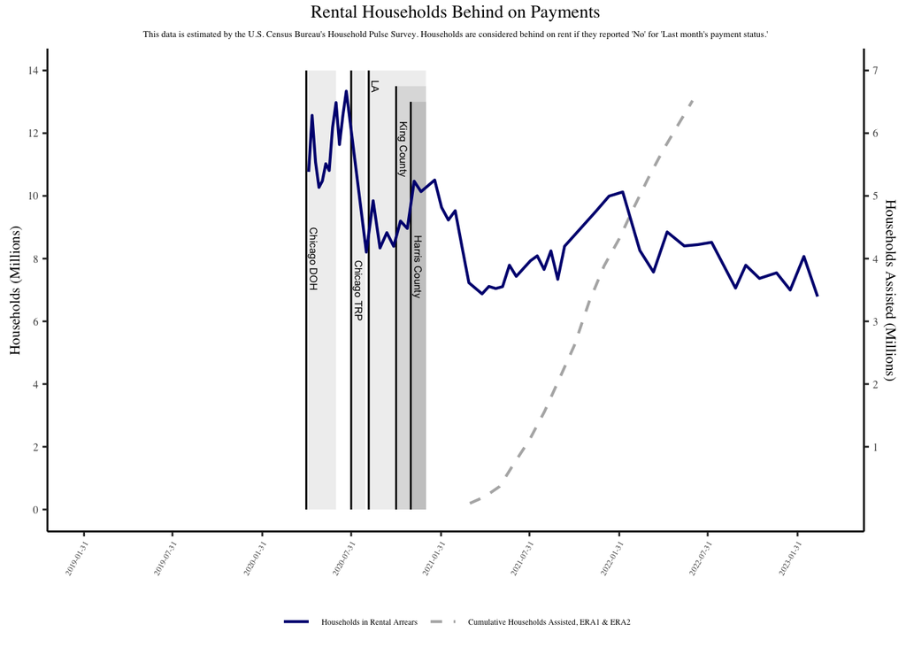

```r
Colors <- c("Cumulative Households Assisted, ERA1 & ERA2" = "grey70", "Households in Rental Arrears" = "navyblue")

# Graph the % of Households in Rental Arrears from May 2020 to October 2023 based on Pulse Survey data #
Rent_Payment_Status_Timeseries_Graph <-
  ggplot() +
  geom_ribbon(
    aes(x = c(as.Date("2020-04-30"), as.Date("2020-06-30")), ymax = c(14,14), ymin = c(0,0)),
    color = NA,
    alpha = 0.6,
    fill = "grey90"
  ) +
  geom_ribbon(
    aes(x = c(as.Date("2020-07-31"), as.Date("2020-08-29")), ymax = c(14,14), ymin = c(0,0)),
    color = NA,
    alpha = 0.6,
    fill = "grey90"
  ) +
  geom_ribbon(
    aes(x = c(as.Date("2020-11-30"), as.Date("2020-12-31")), ymax = c(13,13), ymin = c(0,0)),
    color = NA,
    alpha = 1,
    fill = "grey50"
  ) +
  geom_ribbon(
    aes(x = c(as.Date("2020-10-31"), as.Date("2020-12-31")), ymax = c(13.5,13.5), ymin= c(0,0)),
    color = NA,
    alpha = 0.6,
    fill = "grey70"
  ) +
  geom_ribbon(
    aes(x = c(as.Date("2020-09-01"), as.Date("2020-12-31")), ymax = c(14,14), ymin = c(0,0)),
    color = NA,
    alpha = 0.6,
    fill = "grey90"
  ) +
  geom_line(
    ERA_Payments,
    mapping = aes(y = `Cumulative Households Assisted, ERA1 & ERA2` / 7 * 14, x = Date, color = ID),
    linewidth = 0.75,
    linetype = "dashed"
  ) +
  geom_segment(
    aes(x = as.Date("2020-04-30"), xend = as.Date("2020-04-30"), y = 0, yend = 14),
    color = "black",
    linewidth = 0.5
  ) +
  geom_segment(
    aes(x = as.Date("2020-07-31"), xend = as.Date("2020-07-31"), y = 0, yend = 14),
    color = "black",
    linewidth = 0.5
  ) +
  geom_segment(
    aes(x = as.Date("2020-11-30"), xend = as.Date("2020-11-30"), y = 0, yend = 13),
    color = "black",
    linewidth = 0.5
  ) +
  geom_segment(
    aes(x = as.Date("2020-10-31"), xend = as.Date("2020-10-31"), y = 0, yend = 13.5),
    color = "black",
    linewidth = 0.5
  ) +
  geom_segment(
    aes(x = as.Date("2020-09-05"), xend = as.Date("2020-09-05"), y = 0, yend = 14),
    color = "black",
    linewidth = 0.5
  ) +
  annotate(
    "text", x = as.Date("2020-05-15"), y = 8, label= "Chicago DOH", angle = 270, size = 2, color="black"
  ) +
  annotate(
    "text", x = as.Date("2020-08-15"), y = 7, label="Chicago TRP", angle = 270, size = 2, color="black"
  ) +
  annotate(
    "text", x = as.Date("2020-12-15"), y = 7.75, label="Harris County", angle=270, size = 2, color="black"
  ) +
  annotate(
    "text", x = as.Date("2020-11-15"), y = 11.5, label="King County", angle=270, size = 2, color="black"
  ) +
  annotate(
    "text", x = as.Date("2020-09-18"), y = 13.5, label="LA", angle=270, size = 2, color="black"
  ) +
  geom_line(
    Behind_On_Rent_Data,
    mapping = aes(y = `Households in Rental Arrears`, x = `Date`, color = ID),
    linewidth = 0.75
  ) +
  labs(
    title = paste0("Rental Households Behind on Payments"),
    subtitle = "This data is estimated by the U.S. Census Bureau's Household Pulse Survey. Households are considered behind on rent if they reported 'No' for 'Last month's payment status.'",
    y = "Households (Millions)",
    x = ""
  ) +
  theme(
    text = element_text(family = "Times"),
    plot.title = element_text(size = 10, hjust = 0.5),
    plot.subtitle = element_text(size = 5, hjust = 0.5),
    plot.margin = margin(0.1,0.2,0,0.2, "cm"),
    axis.text = element_text(size = 6, margin = 1),
    axis.title = element_text(size = 8, margin = 1),
    axis.title.x = element_blank(),
    axis.text.x = element_text(angle = 60, vjust = 1, hjust=1, size = 4.5),
    panel.grid = element_blank(),
    panel.border = element_blank(),
    panel.background = element_blank(),
    legend.text = element_text(size = 4.5),
    legend.title = element_blank(),
    legend.spacing.x = unit(1, "cm"),
    legend.spacing.y = unit(0.2, "mm"),
    legend.position = "bottom",
    legend.background = element_blank(),
    axis.line = element_line(colour = "black")
  ) +
  ylab(
    label = "Households (Millions)"
  ) +
  scale_y_continuous(
    limits = c(0,14),
    breaks = seq(0,14, by = 2),
    sec.axis = sec_axis(transform = ~./14 * 7, name = "Households Assisted (Millions)", breaks = seq(1, 7, by  = 1))
  ) +
  scale_x_date(
    limits = c(as.Date("2019-02-01"), as.Date("2023-04-01")),
    breaks = seq(as.Date("2019-02-01"), as.Date("2023-04-01"), by = "6 months") - 1
  ) +
  scale_color_manual(
    values = Colors,
    breaks = c("Households in Rental Arrears", "Cumulative Households Assisted, ERA1 & ERA2")
  ) +
  guides(
    color = guide_legend(position = "bottom")
  )

Rent_Payment_Status_Timeseries_Graph
```

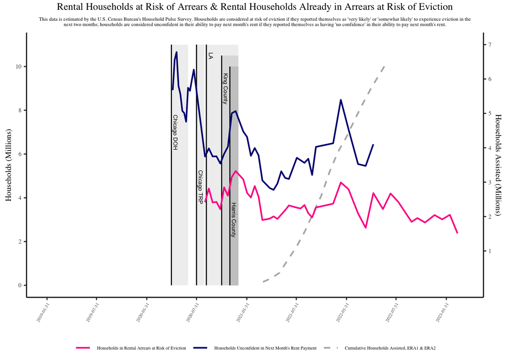

```r
# Combine eviction risk and next rent risk data #
Eviction_and_Next_Rent_Risk_Data <- data.frame(matrix(nrow = length(unique(c(Next_Rent_Risk_Data$Date, Eviction_Risk_Data$Date))), ncol = 3))
colnames(Eviction_and_Next_Rent_Risk_Data) <- c("Date", "Households in Rental Arrears at Risk of Eviction", "Households Unconfident in Next Month's Rent Payment")
Eviction_and_Next_Rent_Risk_Data$Date <- unique(c(Next_Rent_Risk_Data$Date, Eviction_Risk_Data$Date))
for (i in 1:nrow(Eviction_and_Next_Rent_Risk_Data)) {
  ifelse (
    Eviction_and_Next_Rent_Risk_Data$Date[i] %in% Eviction_Risk_Data$Date,
    Eviction_and_Next_Rent_Risk_Data$`Households in Rental Arrears at Risk of Eviction` [i] <- Eviction_Risk_Data$`Households in Rental Arrears at Risk of Eviction`[Eviction_Risk_Data$Date == Eviction_and_Next_Rent_Risk_Data$Date[i]],
    Eviction_and_Next_Rent_Risk_Data$`Households in Rental Arrears at Risk of Eviction`[i] <- 0
  )

  ifelse (
    Eviction_and_Next_Rent_Risk_Data$Date[i] %in% Next_Rent_Risk_Data$Date,
    Eviction_and_Next_Rent_Risk_Data$`Households Unconfident in Next Month's Rent Payment`[i] <- Next_Rent_Risk_Data$`Households Unconfident in Next Month's Rent Payment`[Next_Rent_Risk_Data$Date ==  Eviction_and_Next_Rent_Risk_Data$Date[i]],
    Eviction_and_Next_Rent_Risk_Data$`Households Unconfident in Next Month's Rent Payment`[i] <- 0
  )
}

# Melt the data #
Eviction_and_Next_Rent_Risk_Data$Date <- as.character(Eviction_and_Next_Rent_Risk_Data$Date)
Eviction_and_Next_Rent_Risk_Data <- melt(Eviction_and_Next_Rent_Risk_Data)
colnames(Eviction_and_Next_Rent_Risk_Data) <- c("Date", "Variable", "Households")
Eviction_and_Next_Rent_Risk_Data$Date <- as.Date(Eviction_and_Next_Rent_Risk_Data$Date)
for (i in 1:nrow(Eviction_and_Next_Rent_Risk_Data)) {
  if (Eviction_and_Next_Rent_Risk_Data$`Households`[i] == 0) {
    Eviction_and_Next_Rent_Risk_Data$`Households`[i] <- NA
  }
}

# Specify colors #
Colors <- c("Households in Rental Arrears at Risk of Eviction" = "deeppink", "Households Unconfident in Next Month's Rent Payment" = "navyblue",
            "Cumulative Households Assisted, ERA1 & ERA2" = "grey70")

# Graph the households that are unconfident in their ability to pay next month's rent and the households at risk of eviction in the next two months #
Eviction_Risk_Timeseries_Graph <-
  ggplot() +
  geom_ribbon(
    aes(x = c(as.Date("2020-04-30"), as.Date("2020-06-30")), ymax = c(11,11), ymin = c(0,0)),
    color = NA,
    alpha = 0.6,
    fill = "grey90"
  ) +
  geom_ribbon(
    aes(x = c(as.Date("2020-07-31"), as.Date("2020-08-29")), ymax = c(11,11), ymin = c(0,0)),
    color = NA,
    alpha = 0.6,
    fill = "grey90"
  ) +
  geom_ribbon(
    aes(x = c(as.Date("2020-11-30"), as.Date("2020-12-31")), ymax = c(10,10), ymin = c(0,0)),
    color = NA,
    alpha = 1,
    fill = "grey50"
  ) +
  geom_ribbon(
    aes(x = c(as.Date("2020-10-31"), as.Date("2020-12-31")), ymax = c(10.5,10.5), ymin= c(0,0)),
    color = NA,
    alpha = 0.6,
    fill = "grey70"
  ) +
  geom_ribbon(
    aes(x = c(as.Date("2020-09-01"), as.Date("2020-12-31")), ymax = c(11,11), ymin = c(0,0)),
    color = NA,
    alpha = 0.6,
    fill = "grey90"
  ) +
  geom_line(
    ERA_Payments,
    mapping = aes(y = `Cumulative Households Assisted, ERA1 & ERA2` / 7 * 11, x = Date, color = ID),
    linewidth = 0.75,
    linetype = "dashed"
  ) +
  geom_segment(
    aes(x = as.Date("2020-04-30"), xend = as.Date("2020-04-30"), y = 0, yend = 11),
    color = "black",
    linewidth = 0.5
  ) +
  geom_segment(
    aes(x = as.Date("2020-07-31"), xend = as.Date("2020-07-31"), y = 0, yend = 11),
    color = "black",
    linewidth = 0.5
  ) +
  geom_segment(
    aes(x = as.Date("2020-11-30"), xend = as.Date("2020-11-30"), y = 0, yend = 10),
    color = "black",
    linewidth = 0.5
  ) +
  geom_segment(
    aes(x = as.Date("2020-10-31"), xend = as.Date("2020-10-31"), y = 0, yend = 10.5),
    color = "black",
    linewidth = 0.5
  ) +
  geom_segment(
    aes(x = as.Date("2020-09-05"), xend = as.Date("2020-09-05"), y = 0, yend = 11),
    color = "black",
    linewidth = 0.5
  ) +
  annotate(
    "text", x = as.Date("2020-05-15"), y = 7, label= "Chicago DOH", angle = 270, size = 2, color="black"
  ) +
  annotate(
    "text", x = as.Date("2020-08-15"), y = 4.5, label="Chicago TRP", angle = 270, size = 2, color="black"
  ) +
  annotate(
    "text", x = as.Date("2020-12-15"), y = 3, label="Harris County", angle=270, size = 2, color="black"
  ) +
  annotate(
    "text", x = as.Date("2020-11-15"), y = 9, label="King County", angle=270, size = 2, color="black"
  ) +
  annotate(
    "text", x = as.Date("2020-09-22"), y = 10.5, label="LA", angle=270, size = 2, color="black"
  ) +
  geom_line(
    Eviction_and_Next_Rent_Risk_Data,
    mapping = aes(y = `Households`, x = `Date`, color = Variable),
    linewidth = 0.75
  ) +
  labs(
    title = paste0("Rental Households at Risk of Arrears & Rental Households Already in Arrears at Risk of Eviction"),
    subtitle = "This data is estimated by the U.S. Census Bureau's Household Pulse Survey. Households are considered at risk of eviction if they reported themselves as 'very likely' or 'somewhat likely' to experience eviction in the
next two months; households are considered unconfident in their ability to pay next month's rent if they reported themselves as having 'no confidence' in their ability to pay next month's rent.",
    y = "Households (Millions)",
    x = ""
  ) +
  theme(
    text = element_text(family = "Times"),
    plot.title = element_text(size = 10, hjust = 0.5),
    plot.subtitle = element_text(size = 5, hjust = 0.5),
    plot.margin = margin(0.1,0.2,0,0.2, "cm"),
    axis.text = element_text(size = 6, margin = 1),
    axis.title = element_text(size = 8, margin = 1),
    axis.title.x = element_blank(),
    axis.text.x = element_text(angle = 60, vjust = 1, hjust=1, size = 4.5),
    panel.grid = element_blank(),
    panel.border = element_blank(),
    panel.background = element_blank(),
    legend.text = element_text(size = 4.5),
    legend.title = element_blank(),
    legend.spacing.x = unit(1, "cm"),
    legend.spacing.y = unit(0.2, "mm"),
    legend.position = "bottom",
    legend.background = element_blank(),
    axis.line = element_line(colour = "black")
  ) +
  ylab(
    label = "Households (Millions)"
  ) +
  scale_y_continuous(
    limits = c(0,11),
    breaks = seq(0,10, by = 2),
    sec.axis = sec_axis(transform = ~./11 * 7, name = "Households Assisted (Millions)", breaks = seq(1, 7, by = 1))
  ) +
  scale_color_manual(
    values = Colors,
    name = "",
    breaks = c("Households in Rental Arrears at Risk of Eviction", "Households Unconfident in Next Month's Rent Payment", "Cumulative Households Assisted, ERA1 & ERA2")
  ) +
  scale_x_date(
    limits = c(as.Date("2019-02-01"), as.Date("2023-04-01")),
    breaks = seq(as.Date("2019-02-01"), as.Date("2023-04-01"), by = "6 months") - 1
  ) +
  guides(
    color = guide_legend(position = "bottom")
  )

Eviction_Risk_Timeseries_Graph
```

# 6 Creating a single PDF

Run the following code to produce a single pdf with all of the figures, removing the comment characters from the last four lines.

```r
# Combine graphs #
Graphs_Page_1 <- ggarrange(Income_Timeseries_Graph, Unemployment_Timeseries_Graph, heights = c(1,1), nrow = 2)
Graphs_Page_2 <- ggarrange(Household_Pulse_Survey_Graph, heights = c(1,1), nrow = 2)

# pdf("The Effects of ERA During the Pandemic Figure.pdf")
# print(Graphs_Page_1)
# print(Graphs_Page_2)
# dev.off()
```